# VIC: Introduction to Visual Computing - 2020

## Assignment 1

This assignment has three problems that you need to address.

Let us load the required libraries first.

```python
!pip install opencv-python
!pip install cv2
```

```
ERROR: Could not find a version that satisfies the requirement cv2
ERROR: No matching distribution found for cv2
```

```python
from __future__ import print_function
import cv2
import numpy as np
from PIL import Image
import matplotlib.pyplot as plt
%matplotlib inline
from scipy import ndimage
from scipy import stats
import math
```

## 1. The Bilateral Filter

For the first problem, we will have to implement the bilateral filter for smoothingof the images.

- You can use the valve image that you can find in your folder to validate the filter.
- Test the filtering and plot the results for neighhoods of 3x3 and 5x5
- Evaluate the performance with the Gaussian smoothing visually and write a small comment with some conclusions

```python
def bilateral_filtering(img, neigh=3, sigma_s=2.5, sigma_r=2.5): #weigthed gaussian to take into account the smoothness of the image
    """
    The Bilateral Filtering.

    Inputs:
        img              The input image
        neigh            The neighborhoud of pixels

    Outputs:
        bilateral_img    A smoothed image
    """

    # Write the function here
    def dist_pixels(x, y, i, j):
        return np.sqrt((x-i)**2 + (y-j)**2)

    def gaussian(x, sigma):
        scipy.stats.norm(0, 1).pdf(0)
        return  (1.0 / (2 * math.pi * (sigma ** 2))) * math.exp(- (x ** 2) / (2 * sigma ** 2))

    def filter_one_pixel(image, x, y, d, sig_s, sig_r):
        radius = d/2
        pixel_filtered = 0
        i = 0
        while i < d:
            j = 0

            while j < d:
                neighbour_x = x - (radius - i)
                neighbour_y = y - (radius - j)
                if neighbour_x >= len(image):
                    neighbour_x -= len(image)
                if neighbour_y >= len(image[0]):
                    neighbour_y -= len(image[0])
                g_r = stats.norm(0, sig_r).pdf(int(image[neighbour_x][neighbour_y]) - int(image[x][y]))
                g_s = stats.norm(0, sig_s).pdf(dist_pixels(neighbour_x, neighbour_y, x, y))

                pixel_filtered += image[neighbour_x][neighbour_y] * g_r * g_s
                j += 1

            i += 1

        return pixel_filtered

    #Apply filter to every pixel - very long
    bilateral_img = np.zeros(img.shape)
    x = 0
    while x < len(img):
        y = 0

        while y < len(img[0]):
            bilateral_img[x][y] = filter_one_pixel(img, x, y, neigh, sigma_s, sigma_r)
            y += 1

        print("line:", x)
        x += 1


    # Return the result
    return bilateral_img
```

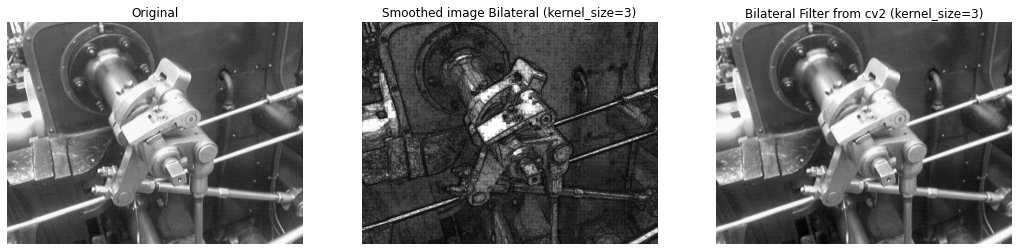

```python
img = cv2.imread('valve.png')
img = cv2.cvtColor(img, cv2.COLOR_RGB2GRAY)

#bilateral = bilateral_filter_own(img, 3, 2.5, 2.5) ## Very long to run
bilateral2 = cv2.bilateralFilter(img,3,75,75)

plt.figure(figsize=(18,6))

plt.subplot(1, 3, 1)
plt.imshow(img, cmap = 'gray')
plt.axis('off')
plt.title('Original')

plt.subplot(1, 3, 2)
plt.imshow(bilateral, cmap = 'gray')
plt.axis('off')
plt.title('Smoothed image Bilateral (kernel_size=3)')

img_gauss = ndimage.gaussian_filter(img, sigma = 1, mode = 'wrap')
plt.subplot(1, 3, 3)
plt.imshow(bilateral2, cmap = 'gray')
plt.axis('off')
plt.title('Bilateral Filter from cv2 (kernel_size=3)')

plt.show()
```

**--> The bilateral filter is much stronger than the one from the cv2 library. The result is not satisfactory in terms of smoothing. However the contrasted edges help with the next step of edge detection.**

## 2. The Canny edge detector

For the first problem, we will implement our own Canny edge detector. Recall that the Canny edge detector consists of the following steps:

- Smoothing the image using a Gaussian filter
- Computing the gradient of the image—magnitude and direction—using the Sobel operator
- Non-maximum suppression using the gradient's magnitude and direction
- Double thresholding
- Edge connectivity using hysterisis

#### 2.A Smoothing

This standard smoothing operation can be implemented using the `gaussian_filter` function found in `sklearn.ndimage`. Alternatively, you can use the following Gaussian filter:

```
G = np.array([[2, 4,  5,  2,  2],
               [4, 9,  12, 9,  4],
               [5, 12, 15, 12, 5],
               [4, 9,  12, 9,  4],
               [2, 4,  5,  4,  2]]) / 156;
```

#### 2.B Gradients

Use the Sobel operators to compute $g_x$ and $g_y$. The magnitude and direction of the gradient can be computed as $\sqrt{g_x^2 + g_y^2}$, and $\arctan\left(\frac{g_y}{g_x}\right)$

#### 2.C Non-maximum suppression

We will take a simplistic approach to non-maximum suppression. First, we quantise the gradient directions into four values—$0$, $\frac{\pi}{4}$, $\frac{\pi}{2}$, and $\frac{3\pi}{4}$. Next, we suppress gradients at all points that are not greater than the two neighbours found when moving in the direction perpendicular to the edge.

#### 2.D Double thresholding

Double thresholding can be implemented by fixing two thresholds, `lo` and `hi`. Accordingly, we will have two *levels* of gradient magnitudes—*weak* and *strong*. Pixels where the magnitude of the gradient is greater than `hi` will be designated *strong* points, while those where it lies between `lo` and `high` will be designated *weak*.

#### 2.E Edge connectivity

Finally, we decide on edge connectivity as follows:

- All pixels with strong gradients belong to edges, termed *definite edges*.
- All pixels with weak gradients belong to edges only if they are connected to definite edges.

Given below is a template for the Canny edge detector. Your task is to complete this function, and write any supporting functions necessary. You are, of course, free to diverge from this template, if you so wish.

```python
def gradient(smoothed):

    #Sobel operators
    Kx = np.array([[-1, 0, 1], [-2, 0, 2], [-1, 0, 1]], np.float32)
    Ky = np.array([[1, 2, 1], [0, 0, 0], [-1, -2, -1]], np.float32)

    Ix = ndimage.filters.convolve(smoothed, Kx)
    Iy = ndimage.filters.convolve(smoothed, Ky)

    #Magnitude, Direction
    G = np.hypot(Ix, Iy)
    G = G / G.max() * 255
    theta = np.arctan2(Iy, Ix)

    return (G.astype(int), theta)
```

```python
def non_maximum_suppression(img, direction):
    M, N = img.shape
    Z = np.zeros((M,N), dtype=np.int32)
    angle = direction * 180. / np.pi
    angle[angle < 0] += 180

    for i in range(1,M-1):
        for j in range(1,N-1):
            try:
                q = 255
                r = 255

               #angle 0
                if (0 <= angle[i,j] < 22.5) or (157.5 <= angle[i,j] <= 180):
                    q = img[i, j+1]
                    r = img[i, j-1]
                #angle 45
                elif (22.5 <= angle[i,j] < 67.5):
                    q = img[i+1, j-1]
                    r = img[i-1, j+1]
                #angle 90
                elif (67.5 <= angle[i,j] < 112.5):
                    q = img[i+1, j]
                    r = img[i-1, j]
                #angle 135
                elif (112.5 <= angle[i,j] < 157.5):
                    q = img[i-1, j-1]
                    r = img[i+1, j+1]

                if (img[i,j] >= q) and (img[i,j] >= r):
                    Z[i,j] = img[i,j]
                else:                    Z[i,j] = 0

            except IndexError as e:
                pass

    return Z
```

```python
def double_thresholding(img, highThresholdRatio, lowThresholdRatio):

    highThreshold = img.max() * highThresholdRatio
    lowThreshold = highThreshold * lowThresholdRatio

    M, N = img.shape
    res = np.zeros((M,N), dtype=np.int32)

    weak = np.int32(25)
    strong = np.int32(255)

    strong_i, strong_j = np.where(img >= highThreshold)
    zeros_i, zeros_j = np.where(img < lowThreshold)

    weak_i, weak_j = np.where((img <= highThreshold) & (img >= lowThreshold))

    res[strong_i, strong_j] = strong
    res[weak_i, weak_j] = weak

    return res, weak, strong
```

```python
def connectivity(img, weak, strong):
    M, N = img.shape
    for i in range(1, M-1):
        for j in range(1, N-1):
            if (img[i,j] == weak):
                try:
                    if ((img[i+1, j-1] == strong) or (img[i+1, j] == strong) or (img[i+1, j+1] == strong)
                        or (img[i, j-1] == strong) or (img[i, j+1] == strong)
                        or (img[i-1, j-1] == strong) or (img[i-1, j] == strong) or (img[i-1, j+1] == strong)):
                        img[i, j] = strong
                    else:
                        img[i, j] = 0
                except IndexError as e:
                    pass

    return img
```

```python
def canny_edge_detector(img, thresh_lo=0.1, thresh_hi=0.2):
    """
    The Canny edge detector.

    Inputs:
        img              The input image
        thresh_lo        The fraction of the maximum gradient magnitude which will
                         be considered the lo threshold.
        thresh_hi        The fraction of the maximum gradient magnitude which will
                         be considered the hi threshold. Ideally should be 2x to 3x
                         thresh_lo.

    Outputs:
        edge_img         A binary image, with pixels lying on edges marked with a 1,
                         and others with a 0.    """


    # Smooth the image first.
    smoothed                     = ndimage.gaussian_filter(img, sigma = 3, mode = 'wrap')

    # Find gradient magnitude and direction
    g_magnitude, g_dir           = gradient(smoothed)

    # Non-maximum suppression
    g_max                        = non_maximum_suppression(g_magnitude, g_dir)

    # Double thresholding
    thresh_img, weak_g, strong_g = double_thresholding(g_max, thresh_lo, thresh_hi)


    # Final edge connectivity
    edge_img                     = connectivity(thresh_img, weak_g, strong_g)

    # Return the result
    return edge_img
```

Now test the code on a sample image—

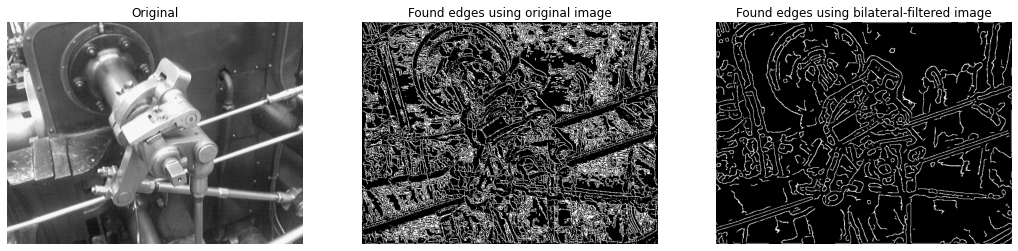

```python
img   = cv2.imread('valve.png')
img   = cv2.cvtColor(img, cv2.COLOR_RGB2GRAY)

edges_img = canny_edge_detector(img)
edges_bilat = canny_edge_detector(bilateral)

plt.figure(figsize=(18,6))

plt.subplot(1, 3, 1)
plt.imshow(img, cmap = 'gray')
plt.axis('off')
plt.title('Original')

plt.subplot(1, 3, 2)
plt.imshow(edges_img, cmap = 'gray')
plt.axis('off')
plt.title('Found edges using original image')

plt.subplot(1, 3, 3)
plt.imshow(edges_bilat, cmap = 'gray')
plt.axis('off')
plt.title('Found edges using bilateral-filtered image')

plt.show()
```

**---> When using the raw image the edges are dectected but there is still of lot of noice. The very strong bilateral filtered built in the first part allow to get rid of the part of the noice**

## 3. Stitching two images

For this problem, you are given two images—`left.png` and `right.png`, which were extracted from a bigger image. All we know is that `left.png` lies to the left and a bit above of `right.png`, and there is an overlapping region between the two. Your task will be to *stitch* these images together so that you can form a bigger image out of two smaller images.

Let us load the images first.

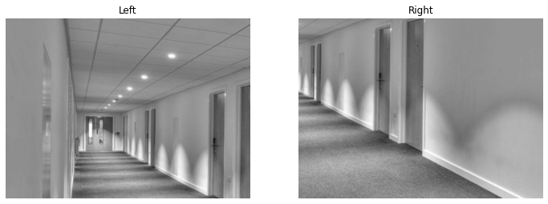

```python
left_img   = cv2.imread('left.png')
left_img   = cv2.cvtColor(left_img, cv2.COLOR_RGB2GRAY)

right_img  = cv2.imread('right.png')
right_img  = cv2.cvtColor(right_img, cv2.COLOR_RGB2GRAY)

plt.figure(figsize=(12,6))

plt.subplot(1, 2, 1)
plt.imshow(left_img, cmap='gray')
plt.axis('off')
plt.title('Left')

plt.subplot(1, 2, 2)
plt.imshow(right_img, cmap='gray')
plt.axis('off')
plt.title('Right')

plt.show()
```

We will try to solve this problem using the Harris corner detector and the RANdom SAmple Consensus (RANSAC) algorithm.

The steps are the following—

- Find corner points in both images implementing by your own the Harris corner detector.
- Choose a random pair of points—one from the left image, and the other from the right.
- We will assume that this pair represents the same location in the scene in both images. This gives a translation vector, so the we can superimpose this point in the right image onto the left image.
- The translation gives us an overlapping region, which can be given a similarity score.
- If we keep choosing this pair of points randomly, we can keep improving our similarity score until we have found the best match.

Your task now is the complete the following code.

### Supporting functions

```python
def harris_corner_detector(img):
    #Detector parameters
    blockSize = 2
    apertureSize = 3
    k = 0.04

    dst = cv2.cornerHarris(img, blockSize, apertureSize, k)

    #result is dilated for marking the corners, not important
    dst = cv2.dilate(dst,None)

    # Threshold for an optimal value, it may vary depending on the image.
    t = 0.05
    #img[dst>t*dst.max()] = 255
    #img[dst<t*dst.max()] = 0

    return np.where(dst>t*dst.max())
```

```python
import random, math

def find_random_pair(corners_left, corners_right):
    i_l = random.randint(0, len(corners_left[0])-1)
    i_r = random.randint(0, len(corners_right[0])-1)
    while corners_right[1][i_r] > corners_left[1][i_l]:
        i_r = random.randint(0, len(corners_right[0])-1)

    corner_l = (corners_left[0][i_l], corners_left[1][i_l])
    corner_r = (corners_right[0][i_r], corners_right[1][i_r])

    return corner_l, corner_r

def find_translation_vector(c_left, c_right):
    vect_x = abs(c_right[1] - c_left[1])
    vect_y = abs(c_right[0] - c_left[0])

    return vect_x, vect_y

def compute_error(img_l, img_r, vect_x, vect_y):
    err = 0
    h, l = img_l.shape

    for i in range(0, h - vect_y):
        for j in range(0, l - vect_x):
            pixel_r = img_r[i][j]
            pixel_l = img_l[vect_y + i][vect_x + j]
            err += (int(pixel_r) - int(pixel_l))**2

    return np.sqrt(err)

def build_stiched_img(img_l, img_r, best_trans, best_corners):
    h, l = img_l.shape
    stiched_image_shape = (h + best_trans[1], l + best_trans[0])
    stitched_image = np.zeros(stiched_image_shape)

    c_left, c_right = best_corners

    leftUp = True if c_left[0] >= c_right[0] else False
    print(leftUp)

    if leftUp:
        stitched_image[0:h, 0:l] = img_l
        stitched_image[best_trans[1]:best_trans[1] + h, best_trans[0]:best_trans[0] + l] = img_r

    else:
        stitched_image[0:h, best_trans[0]:best_trans[0] + l] = img_r
        stitched_image[best_trans[1]:best_trans[1] + h, 0:l] = img_l

    return stitched_image
```

### Stiching Algorithm

```python
def stitch_images(left, right, max_tries=1000):
    # Find corner points
    corners_left  = harris_corner_detector(left)
    corners_right = harris_corner_detector(right)

    best_error = 255*left.shape[0]*left.shape[1]
    best_trans = None
    best_corners = None

    for n_try in range(max_tries):
        # Choose two points randomly
        c_left, c_right  = find_random_pair(corners_left, corners_right)

        # Get translation vector
        x_trans, y_trans = find_translation_vector(c_left, c_right)

        # Compute resulting error.
        this_error       = compute_error(left, right, x_trans, y_trans)

        if this_error < best_error:
            best_error   = this_error
            best_trans   = x_trans, y_trans
            best_corners = c_left, c_right

    return best_corners, build_stiched_img(left, right, best_trans, best_corners)
```

### Example

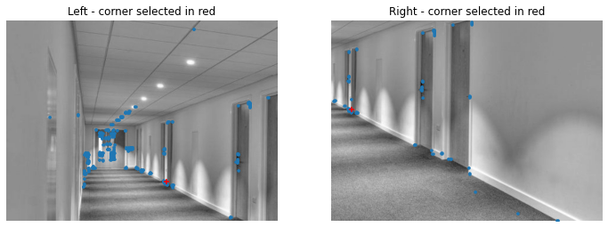

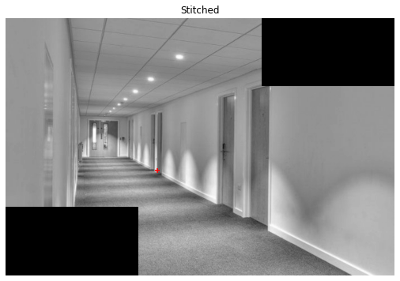

```python
d = harris_corner_detector(left_img)
dr = harris_corner_detector(right_img)

best_c, stiched = stitch_images(left_img, right_img, max_tries=50)

plt.figure(1, figsize=(12, 6))

plt.subplot(1, 2, 1)
plt.imshow(left_img, cmap='gray')
plt.axis('off')
plt.title('Left - corner selected in red')
plt.scatter(d[1], d[0], s=1)
plt.scatter(best_c[0][1], best_c[0][0], c='red', marker = '+')

plt.subplot(1, 2, 2)
plt.imshow(right_img, cmap='gray')
plt.axis('off')
plt.title('Right - corner selected in red')
plt.scatter(dr[1], dr[0], s=1)
plt.scatter(best_c[1][1], best_c[1][0], c='red', marker = '+')

plt.figure(2, figsize=(10, 6))

plt.imshow(stiched, cmap = 'gray')
plt.axis('off')
plt.title('Stitched')
plt.scatter(best_c[0][1], best_c[0][0], c='red', marker = '+')
```

**---> Succesful reconstruction of the image**

**Remark.** Note that in this simplified problem setting, we assumed only translations along $x-$ and $y-$axes. However, in a real-world scenario, we can expect any affine transformation and/or viewpoint differences between the two images. This means we can no longer decide correspondences using only one pair of points. Can you think of a strategy that can be employed in such a scenario?

**---> We can deal with rotation by matching two pairs of corners intead of only one. This allows to compute the rotation angle and reverse it. To deal with tilted images (differents points of view of the scene) we would need at least 3 paires of matching corners to reconstructed the transformation.**